# 統計学2

カイ二乗分布と母分散の推定

矢内 勇生

2018-05-16（改訂：2018-05-17）

# 母分散と標本の分散

## 母集団の設定

母集団（成人男性全体）では、平均身長が170cm、身長の標準偏差が6cm であり、身長は正規分布に従うことを知っているとする。つまり、母分散は $6^2 = 36$ である。

```r
mu <- 170     # 母平均
sigma <- 6    # 母標準偏差
pop <- rnorm(10^6, mean = mu, sd = sigma)
```

母集団の身長分布は以下のようになる。

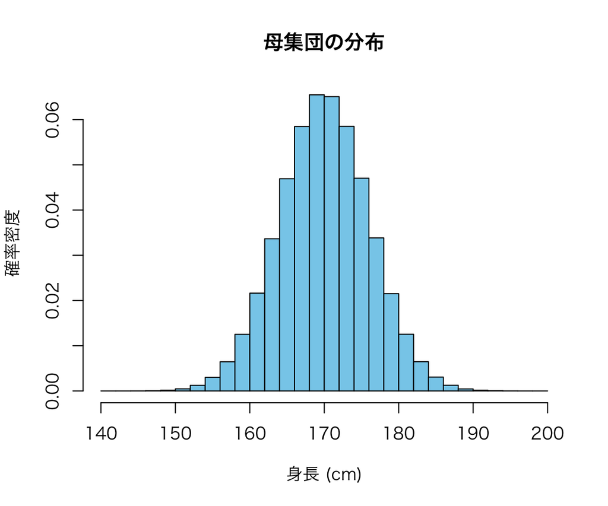

```r
hist(pop, prob = TRUE, col = "skyblue",
     main = "母集団の分布", xlab = "身長 (cm)", ylab = "確率密度")
```

以下では、様々な標本サイズで標本を抽出し、その標本の分散を求める作業を 繰り返すことで、分散に対する理解を深めよう。

## 標本の分散

身長の観測値を $x$ で現すことにしよう。統計学1で（おそらく）学んだとおり、$x$ の分散 $s^2$ は、以下の式で定義される。
$$s^2 = \frac{1}{n}\sum_{i=1}^n (x_i - \bar{x})^2$$
ただし、$n$ は標本サイズである。

$n=10$ として母集団から標本を1つ抽出し、この分散を計算してみよう。

```r
n <- 10
smpl_1 <- sample(pop, size = 10, replace = FALSE)
```

抽出した標本について、1つひとつの値 ($x_1, x_2, \dots, x_{10}$) を確認する。

```r
smpl_1
```

```
##  [1] 175.7723 163.8309 173.8970 176.5091 161.1755 172.1482 169.9440
##  [8] 164.7393 165.6629 164.9124
```

次に、偏差 (deviation) $x - \bar{x}$ を計算する。

```r
(dev_1 <- smpl_1 - mean(smpl_1))
```

```
##  [1]  6.913121 -5.028296  5.037844  7.649967 -7.683695  3.289069  1.084874
##  [8] -4.119859 -3.196253 -3.946773
```

偏差の二乗 (squares) を計算する。

```r
(devsq_1 <- dev_1^2)
```

```
##  [1] 47.791240 25.283762 25.379874 58.521988 59.039169 10.817977  1.176952
##  [8] 16.973235 10.216032 15.577014
```

偏差の二乗を合計する（これを**偏差平方和**と呼ぶ）。

```r
(ssd_1 <- sum(devsq_1))
```

```
## [1] 270.7772
```

これを標本サイズ $n$ で割ったものが、標本の分散 $s^2$ である。

```r
ssd_1 / n
```

```
## [1] 27.07772
```

毎回この作業をするのは面倒なので、標本分散を計算する関数を作ってしまおう。

```r
get_var <- function(x) {
  ## 標本の分散を計算する関数
  ## x は1つの標本（値が複数入ったベクトル）
  n <- length(x)      # 標本サイズを求める
  dev <- x - mean(x)  # 偏差
  ssd <- sum(dev^2)   # 偏差平方和
  return(ssd / n)     # 標本の分散を返す
}
```

この関数を使って、標本の分散を求めてみよう。

```r
get_var(x = smpl_1)
```

```
## [1] 27.07772
```

先ほどと同じ値が得られた。

しかし、Rには分散を求める `var()` という関数がある。この関数を使って分散を求めてみよう。

```r
var(smpl_1)
```

```
## [1] 30.08636
```

答えが一致しない。なぜだろうか。

実は、Rの`var()` が計算しているのは、不偏分散と呼ばれる分散である。この分散は、母分散の不偏推定量である。不偏分散 $u^2$ は、次のように定義される。
$$u^2 = \frac{1}{n-1}\sum_{i=1}^n (x_i - \bar{x})^2.$$
つまり、分散の式の分母を $n$ から $n-1$ に変えたものが不偏分散である。 分母を小さくしているので、分散自体は大きく推定される。このように、あえて分散が大きくなるようにするのは、標本分散 $s^2$ が母分散を過小推定してしまうためである。これをシミュレーションで確かめてみよう。

## 母分散推定のシミュレーション

ここでは、上で定義した母集団から $n=10$ の標本を1万回抽出し、それぞれの標本について、標本分散 $s^2$ と不偏分散 $u^2$ を計算し、分散の分布を確認してみよう。

まず、シミュレーションの設定を行う。

```r
n <- 10
n_sims <- 10000
```

次に、結果を保存するための行列を用意する。保存する対象は2つ（2種類の分散）で、シミュレーションの繰り返し回数が n_sim なので、n_sims行2列の行列を用意する。

```r
res_sim_1 <- matrix(NA, nrow = n_sims, ncol = 2)
```

1列目に標本分散を、2列目に不偏分散を保存する。

```r
names(res_sim_1) <- c("s_sq", "u_sq")
```

forループを使ってシミュレーションを実行する。

```r
for (i in 1:n_sims) {
  x <- sample(pop, size = n, replace = FALSE)
  res_sim_1[i, 1] <- get_var(x)
  res_sim_1[i, 2] <- var(x)
}
```

結果を確認する。まず、標本分散の分布を確認してみよう。

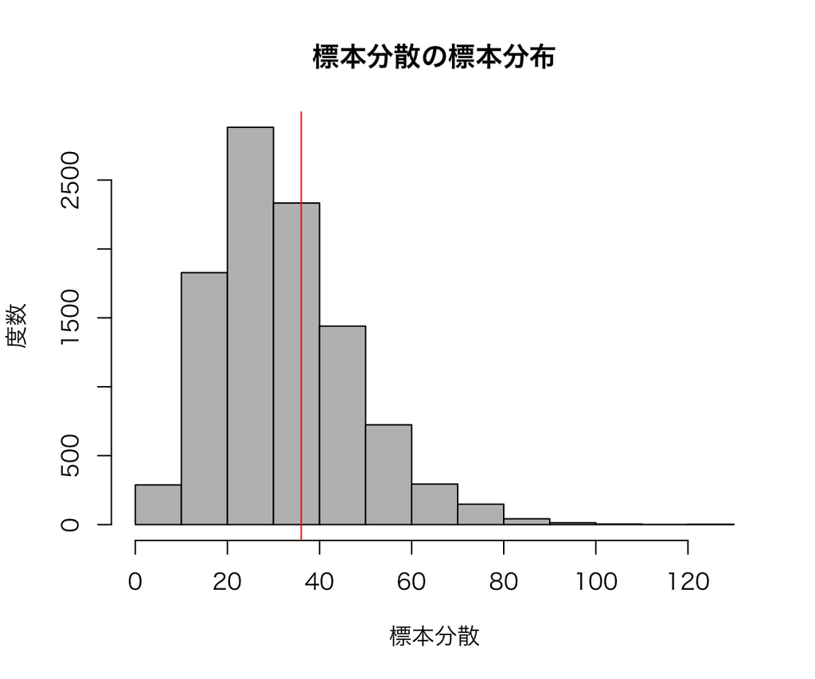

```r
hist(res_sim_1[, 1], col = "gray",
     xlab = "標本分散", ylab = "度数", main = "標本分散の標本分布")
abline(v = get_var(pop), col = "red")
```

標本分散の平均値を確認する。

```r
mean(res_sim_1[, 1])
```

```
## [1] 32.25378
```

母分散（母集団の分散）は、

```r
get_var(pop)
```

```
## [1] 36.01808
```

だから、標本分散の平均値は母分散より小さい。つまり、平均すると、標本分散は母分散を過小推定する。言い換えると、標本分散は偏った推定量である。

同様に、不偏分散を確認してみよう。

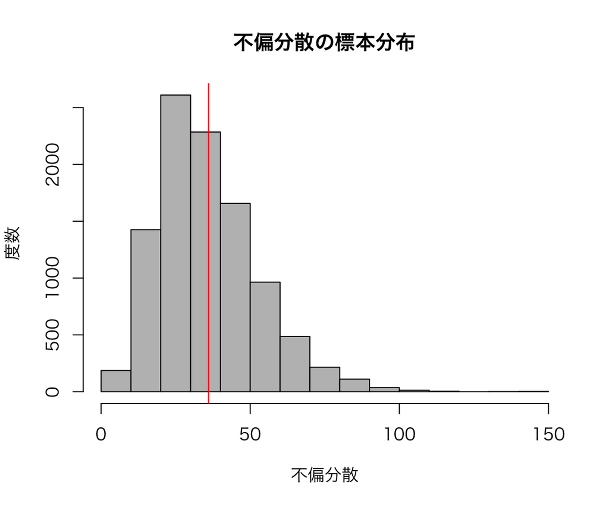

```r
hist(res_sim_1[, 2], col = "gray",
     xlab = "不偏分散", ylab = "度数", main = "不偏分散の標本分布")
abline(v = get_var(pop), col = "red")
```

不偏分散の平均値を確認する。

```r
mean(res_sim_1[, 2])
```

```
## [1] 35.83753
```

母分散（母集団の分散）は、

```r
get_var(pop)
```

```
## [1] 36.01808
```

だから、不偏分散の平均値は、母分散と（ほぼ）同じである。つまり、平均すると、不偏分散は母分散を正しく推定することができる。言い換えると、不偏分散は母分散の不偏推定量である。

# カイ二乗分布を理解する

カイ二乗 ($\chi^2$) 分布は、自由度 $df \geq 1$ によってその形を変える。

たとえば、自由度1, 3, 5, 10のカイ二乗分布は、以下のように分布する。

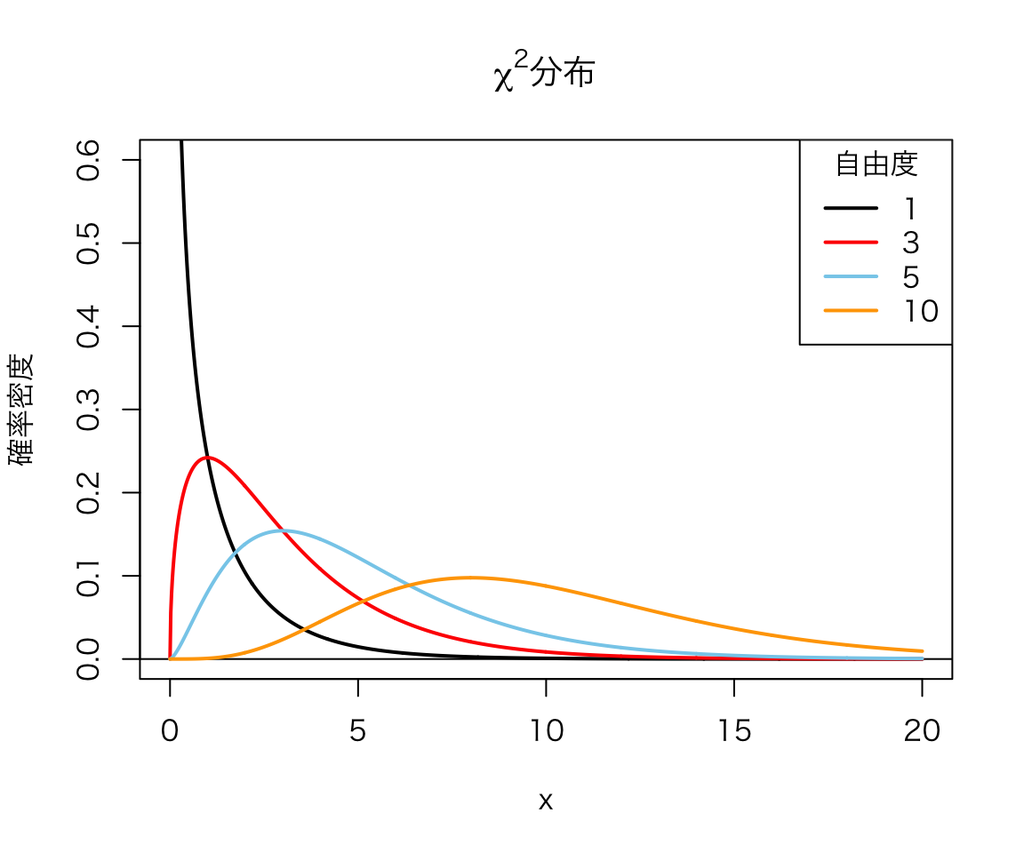

```r
x <- seq(0, 20, length = 1000)
chi1 <- dchisq(x, df = 1)
chi3 <- dchisq(x, df = 3)
chi5 <- dchisq(x, df = 5)
chi10 <- dchisq(x, df = 10)
plot(x, chi1, type = "l", lwd = 2, xlim = c(0, 20), ylim = c(0, 0.6),
     ylab = "確率密度", main = expression(paste(chi^2, "分布")))
abline(h = 0)
lines(x, chi3, lwd = 2, col = "red")
lines(x, chi5, lwd = 2, col = "skyblue")
lines(x, chi10, lwd = 2, col = "orange")
legend("topright", lty = 1, lwd = 2, col = c("black","red","skyblue","orange"),
       legend = c("1", "3",  "5", "10"), title = "自由度")
```

カイ二乗分布の形状を確認するための関数を用意したので、これを使って色々なカイ二乗分布の形状を確認してみよう（この関数の中身を理解する必要はない）。

```r
plot_chisq <- function(df) {
  upper <- max(c(df + 10, df*2))
  x <- seq(from = 0, to = upper, length = 1000)
  chisq <- dchisq(x, df = df)
  plot(x, chisq, type = "l", col = "royalblue", lwd = 1.5,
       ylab = "確率密度",
       main = paste("自由度", df, "のカイ二乗分布"))
}
```

自由度1のカイ二乗分布は、

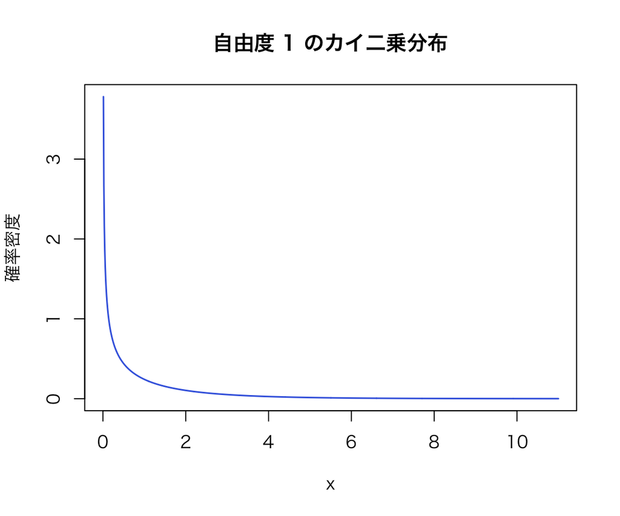

```r
plot_chisq(df = 1)
```

自由度3のカイ二乗分布は、

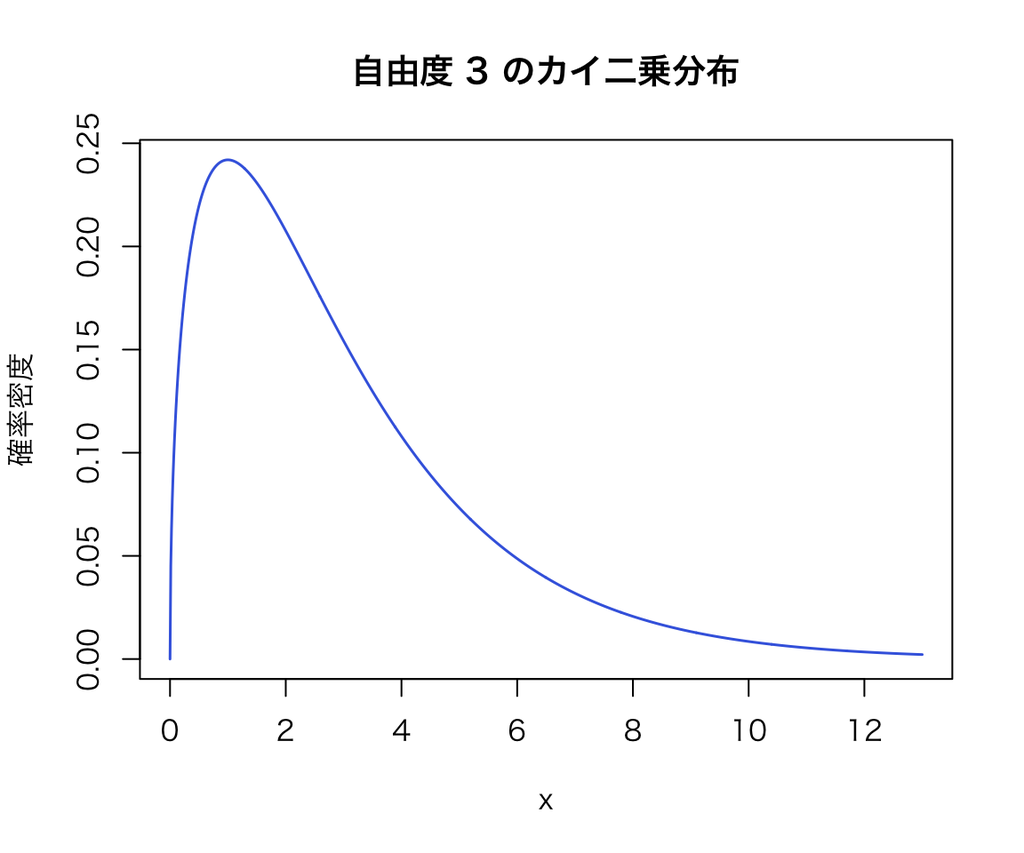

```r
plot_chisq(df = 3)
```

**実習課題：**自由度 (df) の値をによって、カイ二乗分布がどのように変化するか確かめてみよう。

# 母分散の推定

## 点推定

上で定義した母集団から、標本サイズ $n=10$ の標本を1つ取り出す。

```r
smpl_2 <- sample(pop, size = 10, replace = TRUE)
```

この標本から母集団の分散を推定したい場合、点推定値は不偏分散 $u^2$ なので、

```r
var(smpl_2)
```

```
## [1] 51.23188
```

である。

## 区間推定

母分散の区間推定には、自由度 $n-1$ のカイ二乗分布を利用する。 母分散の信頼区間は、
$$\frac{n-1}{\chi_U^2} u^2 \leq \sigma^2 \leq \frac{n-1}{\chi_L^2} u^2$$
と表される。$\chi_L^2$ と$\chi_U^2$には、自由度と信頼区間の信頼度（パーセンテージ）に応じて異なる数字を入れる。

例として、95パーセント信頼区間を求めることにしよう。私たちの標本の大きさは $n=10$なので、自由度は $n-1=9$ である。カイ二乗分布の中心部分95%を推定に利用したい。言い換えると、分布の端にある5％分は除外したい。両端から2.5%ずつ除外することにすると、下側の点である$\chi_L^2$は、

```r
(chisq_lower <- qchisq(p = 0.025, df = 9, lower.tail = TRUE))
```

```
## [1] 2.700389
```

であり、上側の点である$\chi_U^2$は、

```r
(chisq_upper <- qchisq(p = 0.025, df = 9, lower.tail = FALSE))
```

```
## [1] 19.02277
```

であることがわかる。

これらの値を使うと、母分散 $\sigma^2$ の95%信頼区間の下限値は、

```r
(lb <- (n - 1) * var(smpl_2) / chisq_upper)
```

```
## [1] 24.23869
```

となる。同様に、上限値は、

```r
(ub <- (n - 1) * var(smpl_2) / chisq_lower)
```

```
## [1] 170.7483
```

となる。したがって、今回の標本から得られる母分散の95％信頼区間は、[24.24, 170.75] である。

毎回この作業を繰り返すのは面倒なので、母分散の信頼区間を計算する関数を作ってしまおう。 信頼度は選べるようにする。

```r
confint4var <- function(x, level = 0.95) {
  ## 母分散の信頼区間を計算する関数
  ## 引数： x = 標本（観測値のベクトル）
  ##        level = 信頼度（既定値は0.95）
  ## 返り値：不偏分散、信頼区間の下限値、信頼区間の上限値のベクトル
  n <- length(x)
  u_sq <- var(x)
  chisq_l <- qchisq(p = (1 - level) / 2, df = n - 1, lower.tail = TRUE)
  chisq_u <- qchisq(p = (1 - level) / 2, df = n - 1, lower.tail = FALSE)
  lb <- (n - 1) * u_sq / chisq_u
  ub <- (n - 1) * u_sq / chisq_l
  return(c(var = u_sq, lb = lb, ub = ub))
}
```

試しにこの関数を使ってみよう。

```r
confint4var(smpl_2)
```

```
##       var        lb        ub
##  51.23188  24.23869 170.74829
```

上で計算したのと同じ結果が得られた。

この標本から得られる母分散の87%信頼区間を求めてみよう。

```r
confint4var(smpl_2, level = 0.87)
```

```
##       var        lb        ub
##  51.23188  28.65448 127.62425
```

求める区間は、[28.65, 127.62] である。

# 課題4

日本の成人女性の平均身長が、平均 160cm, 標準偏差 6cm の正規分布にしたがっていると仮定する。 このとき、標本サイズ $n = 100$ の標本を3つ抽出し、それぞれの標本について以下の推定値を求めなさい。

1. 母平均の点推定値
2. 母平均の信頼区間：信頼度は自由に設定してよい
3. 母分散の点推定値
4. 母分散の信頼区間：信頼度は自由に設定してよい
- 提出期限：5月24日（木）の授業開始時
- 結果を印刷したものを提出（Rのコードも付ける。コードがないものは減点する。Rマークダウンを使ってもよい）
- 氏名（ふりがな付き）と学籍番号を忘れずに書く
- 2枚以上（片面印刷で2ページ以上または両面印刷で3ページ以上）提出するときは、すべての紙をホチキス等で綴じること

授業の内容に戻る